# Factors Influencing Deaths In Heart Failure Patients

Project Groups11  
Parth Deshmukh(S3825055), Subbiah Soundarapandian(S3825012), Sudershan Ravi(S3829895)

• **TABLE OF CONTENTS**

1. INTRODUCTION
2. STATISTICAL MODELLING
- MODEL FITTING
- RESIDUAL ANALYSIS
- RESPONSE ANALYSIS
- GOODNESS OF FIT
- CONFIDENCE INTERVALS
- HYPOTHESIS TEST
- SENSITIVITY ANALYSIS
3. FINAL MODEL
4. CRITIQUES AND LIMITATIONS
5. SUMMARY AND CONCLUSIONS
6. REFERENCES

• **INTRODUCTION**

In this phase of the project we will focus majorly on the analysis of probability of mortality using logistic regression model. The binary variable “DEATH EVENT” is used as a response variable. In consideration with the previous analysis in phase-1 it is evident that there are various distinct factors impacting mortality in patients with history of heart failure like age, platelet count, serum creatinine, ejection fraction, diabetes, anaemia, blood pressure levels and habit of smoking. So, in order to extract the conclusive outcomes, we will go through various steps in order to filter out the key features for the binomial logistic regression model. The logistic model is tested for model fitting which will provide a summary to differentiate most significant features. Secondly, residual analysis is performed to make it easy to comment on the appropriateness of the model for the observed value of the dependent and predicted values. In order to be sure with the predictions we are making, visualization of the graphs is done for the response analysis. Further, we will go through the performance of the model and comment on the reliability using the goodness of the fit which would be summoned with the confidence intervals and hypothesis test to have a conclusive result. Finally, after all this analysis we will check through the nature of the model by operating it with other variables by the sensitivity analysis to see how the model react with the change in different parameters. After going through all these process we certainly found some predicted outcomes for mortality.

• **STATISTICAL MODELLING**

1. MODEL FITTING

```r
setwd("C:/Users/parth/OneDrive/Desktop/SEMESTER 2/Analysis of Categorical Data/Project phase 1")
assign_ds <- read.csv("Project Groups11_data.csv")

library(ggplot2)

mod_fit <- glm(formula = DEATH_EVENT ~ age+anaemia+creatinine_phosphokinase+diabetes+ejection_fraction+high_blood_pressure+platelets+serum_creatinine+serum_sodium+sex+smoking,
               family = binomial(link = logit), data = assign_ds)
summary(mod_fit)
```

```
##
## Call:
## glm(formula = DEATH_EVENT ~ age + anaemia + creatinine_phosphokinase +
##     diabetes + ejection_fraction + high_blood_pressure + platelets +
##     serum_creatinine + serum_sodium + sex + smoking, family = binomial(link = logit),
##     data = assign_ds)
##
## Deviance Residuals:
##     Min       1Q   Median       3Q      Max
## -2.3184  -0.7692  -0.4436   0.8293   2.4880
##
## Coefficients:
##                            Estimate Std. Error z value Pr(>|z|)
## (Intercept)               4.964e+00  4.601e+00   1.079 0.280625
## age                       5.569e-02  1.313e-02   4.241 2.23e-05 ***
## anaemia                   4.179e-01  3.009e-01   1.389 0.164904
## creatinine_phosphokinase  2.905e-04  1.428e-04   2.034 0.041907 *
## diabetes                  1.514e-01  2.974e-01   0.509 0.610644
## ejection_fraction        -7.032e-02  1.486e-02  -4.731 2.23e-06 ***
## high_blood_pressure       4.189e-01  3.061e-01   1.369 0.171092
## platelets                -7.094e-07  1.617e-06  -0.439 0.660857
## serum_creatinine          6.619e-01  1.734e-01   3.817 0.000135 ***
## serum_sodium             -5.667e-02  3.338e-02  -1.698 0.089558 .
## sex                      -3.990e-01  3.508e-01  -1.137 0.255394
## smoking                   1.356e-01  3.486e-01   0.389 0.697300
## ---
## Signif. codes:  0 '***' 0.001 '**' 0.01 '*' 0.05 '.' 0.1 ' ' 1
##
## (Dispersion parameter for binomial family taken to be 1)
##
##     Null deviance: 375.35  on 298  degrees of freedom
## Residual deviance: 294.28  on 287  degrees of freedom
## AIC: 318.28
##
## Number of Fisher Scoring iterations: 5
```

```r
mod_fit1 <- glm(formula = DEATH_EVENT ~ age+creatinine_phosphokinase+ejection_fraction+serum_creatinine+serum_sodium,
                family = binomial(link = logit), data = assign_ds)

summary(mod_fit1)
```

```
##
## Call:
## glm(formula = DEATH_EVENT ~ age + creatinine_phosphokinase +
##     ejection_fraction + serum_creatinine + serum_sodium, family = binomial(link = logit),
##     data = assign_ds)
##
## Deviance Residuals:
##     Min       1Q   Median       3Q      Max
## -2.3285  -0.7862  -0.4944   0.8743   2.4401
##
## Coefficients:
##                            Estimate Std. Error z value Pr(>|z|)
## (Intercept)               4.3687048  4.5131808   0.968    0.333
## age                       0.0534293  0.0125564   4.255 2.09e-05 ***
## creatinine_phosphokinase  0.0002091  0.0001350   1.549    0.121
## ejection_fraction        -0.0668476  0.0144514  -4.626 3.73e-06 ***
## serum_creatinine          0.6292991  0.1599542   3.934 8.35e-05 ***
## serum_sodium             -0.0514336  0.0328688  -1.565    0.118
## ---
## Signif. codes:  0 '***' 0.001 '**' 0.01 '*' 0.05 '.' 0.1 ' ' 1
##
## (Dispersion parameter for binomial family taken to be 1)
##
##     Null deviance: 375.35  on 298  degrees of freedom
## Residual deviance: 300.71  on 293  degrees of freedom
## AIC: 312.71
##
## Number of Fisher Scoring iterations: 5
```

```r
vcov(mod_fit1)
```

```
##                            (Intercept)           age creatinine_phosphokinase
## (Intercept)               2.036880e+01 -7.717235e-03             2.765716e-05
## age                      -7.717235e-03  1.576624e-04             2.355803e-07
## creatinine_phosphokinase  2.765716e-05  2.355803e-07             1.822494e-08
## ejection_fraction         3.904581e-03 -4.174055e-05            -4.326825e-08
## serum_creatinine         -1.199406e-01 -4.060361e-05             1.255567e-07
## serum_sodium             -1.455996e-01 -5.766839e-06            -3.854868e-07
##                          ejection_fraction serum_creatinine  serum_sodium
## (Intercept)                   3.904581e-03    -1.199406e-01 -1.455996e-01
## age                          -4.174055e-05    -4.060361e-05 -5.766839e-06
## creatinine_phosphokinase     -4.326825e-08     1.255567e-07 -3.854868e-07
## ejection_fraction             2.088425e-04    -3.300678e-04 -5.966537e-05
## serum_creatinine             -3.300678e-04     2.558533e-02  7.164803e-04
## serum_sodium                 -5.966537e-05     7.164803e-04  1.080355e-03
```

2. RESIDUAL ANALYSIS

```r
####
#Serum_Creatinine
w<-aggregate(formula = DEATH_EVENT ~ serum_creatinine, data = assign_ds,
             FUN = sum)
n<-aggregate(formula = DEATH_EVENT ~ serum_creatinine, data = assign_ds,
             FUN = length)
w.n<-data.frame(Serum_Creatinine = w$serum_creatinine, Death = w$DEATH_EVENT,
                trials = n$DEATH_EVENT, proportion = round(w$DEATH_EVENT/n$DEATH_EVENT,4))
head(w.n)
```

```
##   Serum_Creatinine Death trials proportion
## 1             0.50     0      1     0.0000
## 2             0.60     2      4     0.5000
## 3             0.70     1     19     0.0526
## 4             0.75     0      1     0.0000
## 5             0.80     1     24     0.0417
## 6             0.90     5     32     0.1562
```

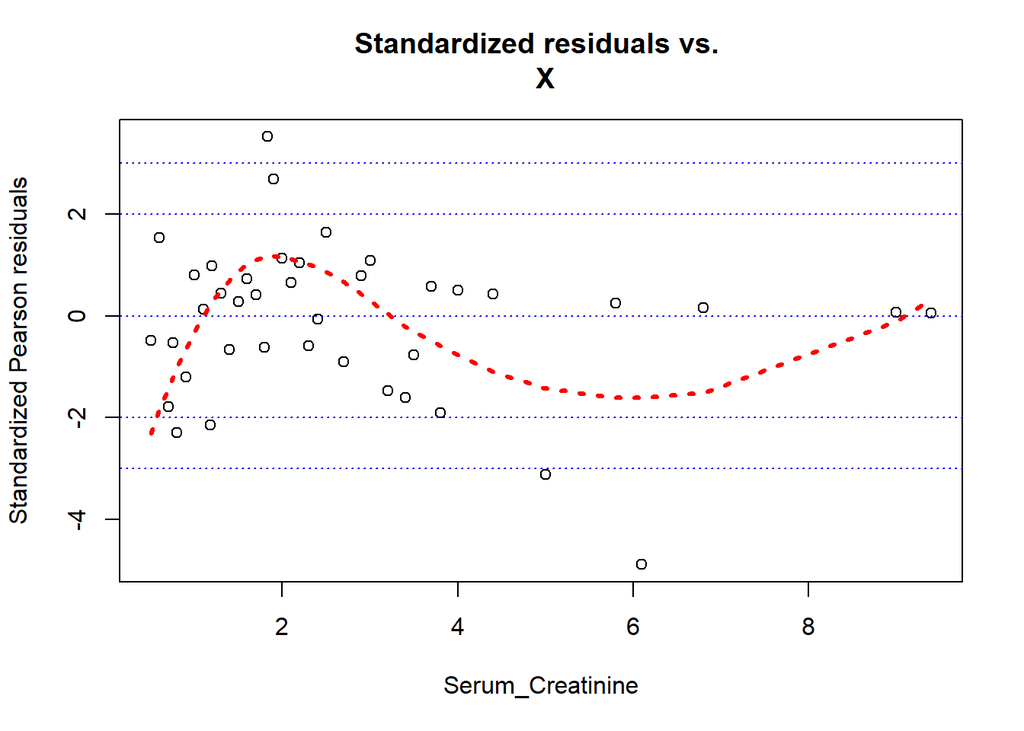

```r
####
mod_fit_group <- glm(formula = Death/trials ~ Serum_Creatinine,weights = trials,
                     family = binomial(link = logit), data = w.n)
pi.hat <- predict(mod_fit_group, type = "response")
p.res <- residuals(mod_fit_group, type = "pearson")
s.res <- rstandard(mod_fit_group, type = "pearson")
lin.pred <- mod_fit_group$linear.predictors
w.n <- data.frame(w.n, pi.hat,p.res, s.res, lin.pred)

#residuals
#continous
plot(x = w.n$Serum_Creatinine, y = w.n$s.res, xlab = "Serum_Creatinine",
     ylab = "Standardized Pearson residuals", main =
       "Standardized residuals vs. \n X")

abline(h = c(3, 2, 0, -2, -3), lty = 3, col = "blue")
# Add loess model to help visualize trend
smooth.stand <- loess(formula = s.res ~ Serum_Creatinine, data =
                        w.n, weights = trials)
# Make sure that loess estimates are ordered by "X" for
#the plots, so that they are displayed properly
order.SC <- order(w.n$Serum_Creatinine)
lines(x = w.n$Serum_Creatinine[order.SC], y =
        predict(smooth.stand)[order.SC], lty = 3, col =
        "red", lwd = 3)
```

```r
#ejection_fraction
w1<-aggregate(formula = DEATH_EVENT ~ ejection_fraction, data = assign_ds,
              FUN = sum)
n1<-aggregate(formula = DEATH_EVENT ~ ejection_fraction, data = assign_ds,
              FUN = length)
w.n1<-data.frame(ejection_fraction = w1$ejection_fraction, Death = w1$DEATH_EVENT,
                 trials = n1$DEATH_EVENT, proportion = round(w1$DEATH_EVENT/n1$DEATH_EVENT,4))
head(w.n1)
```

```
##   ejection_fraction Death trials proportion
## 1                14     1      1     1.0000
## 2                15     2      2     1.0000
## 3                17     1      2     0.5000
## 4                20    16     18     0.8889
## 5                25    18     36     0.5000
## 6                30    13     34     0.3824
```

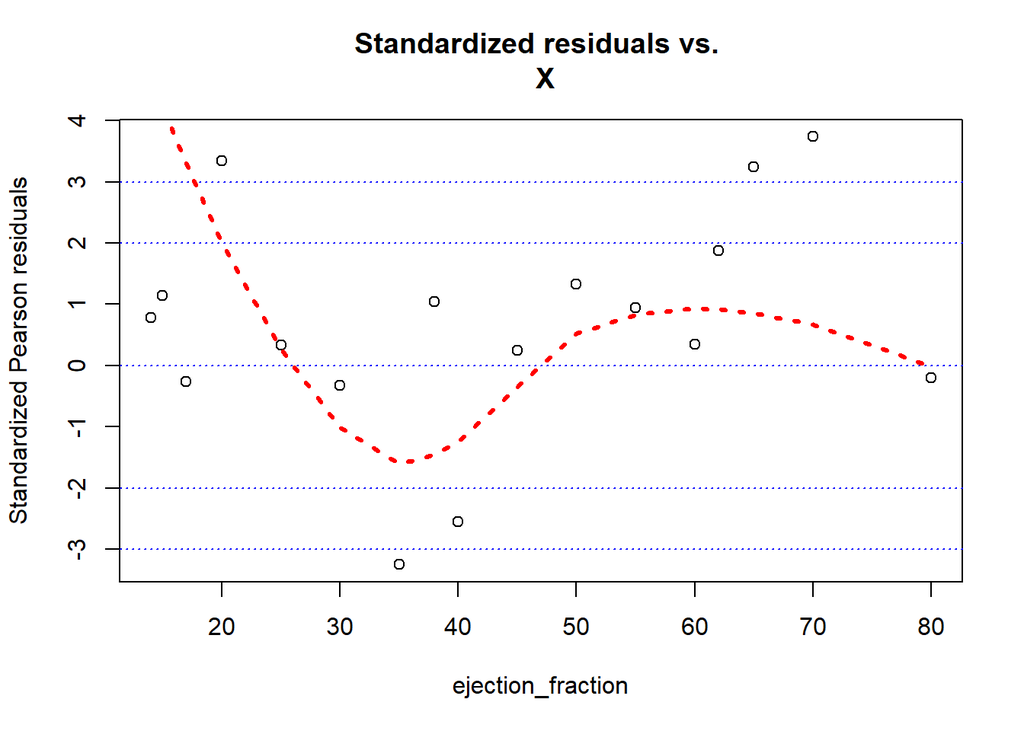

```r
####
mod_fit_group1 <- glm(formula = Death/trials ~ ejection_fraction,weights = trials,
                      family = binomial(link = logit), data = w.n1)
pi.hat <- predict(mod_fit_group1, type = "response")
p.res <- residuals(mod_fit_group1, type = "pearson")
s.res <- rstandard(mod_fit_group1, type = "pearson")
lin.pred <- mod_fit_group1$linear.predictors
w.n1 <- data.frame(w.n1, pi.hat,p.res, s.res, lin.pred)

#residuals
#continous
plot(x = w.n1$ejection_fraction, y = w.n1$s.res, xlab = "ejection_fraction",
     ylab = "Standardized Pearson residuals", main =
       "Standardized residuals vs. \n X")

abline(h = c(3, 2, 0, -2, -3), lty = 3, col = "blue")
# Add loess model to help visualize trend
smooth.stand <- loess(formula = s.res ~ ejection_fraction, data =
                        w.n1, weights = trials)
# Make sure that loess estimates are ordered by "X" for
#the plots, so that they are displayed properly
order.EF <- order(w.n1$ejection_fraction)
lines(x = w.n1$ejection_fraction[order.EF], y =
        predict(smooth.stand)[order.EF], lty = 3, col =
        "red", lwd = 3)
```

3. RESPONSE ANALYSIS

After plotting the graphs it can be examined that Ejection Fraction and Creatinine Phosphokinase seems to be mostly significant as compared to the serum sodium.

```r
library(dplyr)
#Response Analysis
EF <- assign_ds %>% group_by(DEATH_EVENT) %>% summarise(Ejection_Fraction = mean(ejection_fraction))
```

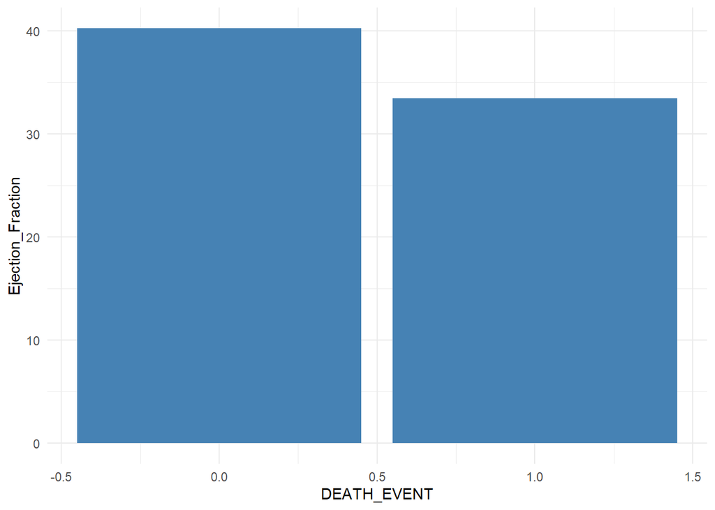

```r
p1 <- ggplot(data=EF, aes(x=DEATH_EVENT, y=Ejection_Fraction)) +
  geom_bar(stat="identity", fill = 'Steel Blue')+
  theme_minimal()
p1
```

```r
SS <- assign_ds %>% group_by(DEATH_EVENT) %>% summarise(serum_sodium = mean(serum_sodium))
```

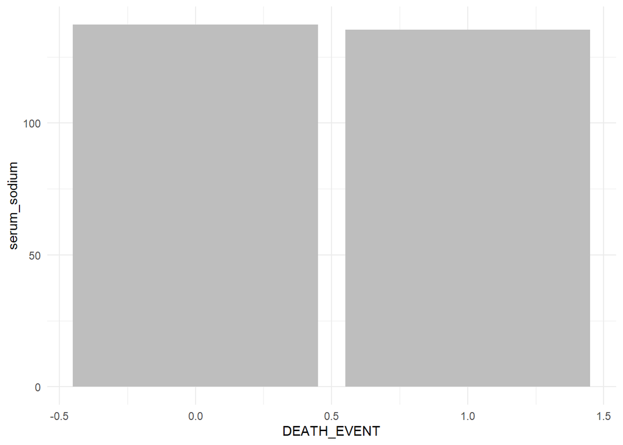

```r
p2 <- ggplot(data=SS, aes(x=DEATH_EVENT, y=serum_sodium)) +
  geom_bar(stat="identity", fill = 'Grey')+
  theme_minimal()
p2
```

```r
CP <- assign_ds %>% group_by(DEATH_EVENT) %>% summarise(creatinine_phosphokinase = mean(creatinine_phosphokinase))
```

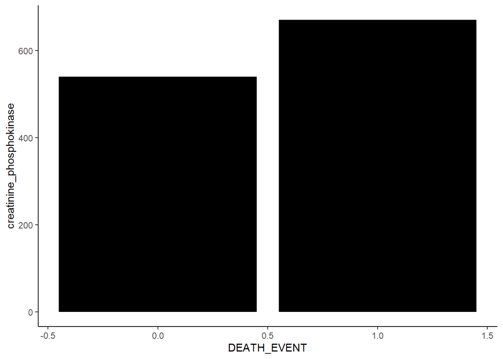

```r
p3 <- ggplot(data=CP, aes(x=DEATH_EVENT, y=creatinine_phosphokinase)) +
  geom_bar(stat="identity", fill = 'black')+
  theme_classic()
p3
```

4. GOODNESS OF FIT

The goodness of fit test is performed using “Hoslem and Lemeshow goodness of fit” to check whether the sample data fits a distribution from a population with a normal distribution. We used this test as it is most efficient way of testing the goodness of fit for the model. It can be observed that we get p-value as 0.2711 which seems to be moderatley good fit.However, good fit would have a p-value around 1.

```r
library("ResourceSelection")
```

```
## ResourceSelection 0.3-5   2019-07-22
```

```r
hoslem.test(mod_fit1$y,mod_fit1$fitted.values)
```

```
##
##  Hosmer and Lemeshow goodness of fit (GOF) test
##
## data:  mod_fit1$y, mod_fit1$fitted.values
## X-squared = 9.9144, df = 8, p-value = 0.2711
```

5. CONFIDENCE INTERVAL

CI for all the regression parameters of the newly fitted model is shown below.

```r
confint(mod_fit1)
```

```
##                                  2.5 %        97.5 %
## (Intercept)              -4.416289e+00 13.3825771287
## age                       2.938756e-02  0.0787866606
## creatinine_phosphokinase -5.822699e-05  0.0004873637
## ejection_fraction        -9.638203e-02 -0.0395594844
## serum_creatinine          3.380334e-01  0.9814098149
## serum_sodium             -1.172304e-01  0.0123820640
```

```r
library(car)
Anova(mod_fit,test= "LR")
```

```
## Analysis of Deviance Table (Type II tests)
##
## Response: DEATH_EVENT
##                          LR Chisq Df Pr(>Chisq)
## age                       19.7820  1  8.680e-06 ***
## anaemia                    1.9397  1    0.16371
## creatinine_phosphokinase   4.1776  1    0.04096 *
## diabetes                   0.2592  1    0.61064
## ejection_fraction         26.6816  1  2.399e-07 ***
## high_blood_pressure        1.8703  1    0.17144
## platelets                  0.1940  1    0.65963
## serum_creatinine          19.7575  1  8.792e-06 ***
## serum_sodium               2.9308  1    0.08691 .
## sex                        1.3018  1    0.25389
## smoking                    0.1513  1    0.69728
## ---
## Signif. codes:  0 '***' 0.001 '**' 0.01 '*' 0.05 '.' 0.1 ' ' 1
```

```r
exp(mod_fit1$coefficients[5])
```

```
## serum_creatinine
##         1.876295
```

```r
1/exp(5*mod_fit1$coefficients[5])
```

```
## serum_creatinine
##       0.04300257
```

• **CRITIQUE AND LIMITATIONS**

This report initially explores all the variables available in the dataset along with the significance of the most impactful influencers of the target variable, thoroughly.  
However, as in every report there are limitations in this analytical report as well. First, the p-value of the Holsem and Lameshow Goodness of Fit Test used to check the model’s fit is calculated to be 0.2711. Though this proves the model is a modest fit as the obtained value is significantly higher than the required p-value of 0.05, the ideal p-value of goodness of fit test would be much closer to 1,if not equal to it.  
Second, the significant effect of influencing variables such as Age, Serum Creatinine Levels, Creatinine Phosphokinase and Ejection Fraction were clear on target variable, Event of Death. The significance of the influencing variables on the target variables is noted to decrease when combined with each other. This phenomenon causes difficulties to predict the outcome of the target variable,Event of Death which in turn, hinders the ability of the analysis to estimate the mortality of the heart patients with an history of heart disease.  
These were the limitations observed in the current analysis in addition to the common limitations of analytical reports such as limited access to data, time constraints and sample size.

• **SUMMARY AND CONCLUSIONS**

The first phase of the analysis explored in detail, the major factors impacting fatality rate inpatients with an history of heart failure. The principal contributors to the patients’ mortality were examined along with the intensity of each of these variables. On studying the results of the first phase, it was evident that the influence of variables such as Age, Serum Creatinine Levels, Creatinine Phosphokinase and Ejection Fraction were significantly higher than that of other variables.  
In the second and final phase of the project, detailed statistical procedures involving binomial logistic regression were performed on the dataset. The statistical procedures included Model Fitting, Residual Analysis, Response Analysis, Goodness of Fit Test involving Hosmer and Lemeshow goodness of fit (GOF) test, Confidence Intervals Calculations, Hypothesis Testing involving Analysis of Variance and Sensitivity Analysis with the help of Odds Ratio Comparison.

• **REFERENCES**

1] Chicco, D., & Jurman, G. (2020). Machine learning can predict survival of patients with heart failure from serum creatinine and ejection fraction alone. BMC Medical Informatics And Decision Making, 20(1). doi: 10.1186/s12911-020-1023-5

2] Heart Failure Prediction. (2020). Retrieved 31 October 2020, from https://www.kaggle.com/andrewmvd/heart-failure-clinical-data